# Билет 2

```python
import numpy as np
import matplotlib.pyplot as plt
import matplotlib
```

### Задача 1

#### Теорема о пределе монотонной ограниченной последовательности

Если $ \{x_n\} $ является неубывающей и ограниченной сверху (невозрастающей и ограниченной снизу), то она сходится ($ \exists \space \lim\limits_{n \to \infty} x_n $)

$ \triangle \space $ Пусть $ \space x_{n + 1} \geqslant x_n \forall \space n \in \mathbb{N}, \exists M \in \mathbb{R}, $ т.ч. $ x_n \leqslant M \space \forall \space n \in \mathbb{N} \Rightarrow \exists \space \bar{x} = sup \{x_n\}. $ Покажем, что $ \bar{x} = \lim\limits_{n \to \infty} x_n $

Возьмём $ \varepsilon > 0 $ По определению $ sup \space \exists N \in \mathbb{N}, $ т.ч. $ \bar{x} - \varepsilon < x_n \leqslant \bar{x}. $ В силу монотонности $ \{x_n\}, \forall n \geqslant N: \bar{x} - \varepsilon < x_n \leqslant \bar{x} < \bar{x} + \varepsilon \Rightarrow |x_n - \bar{x}| < \varepsilon \ \forall \space n \geqslant N \Leftrightarrow \lim\limits_{n \to \infty} x_n= \bar{x} $

### Задача 2

#### Определение, свойства и график функции $ y=cos x $

$ X = \mathbb{R} $, $ Y = [-1, 1] $

Функция чётная, периодическая ($ T = 2\pi $).

Функция непрерывна на $ \mathbb{R} $

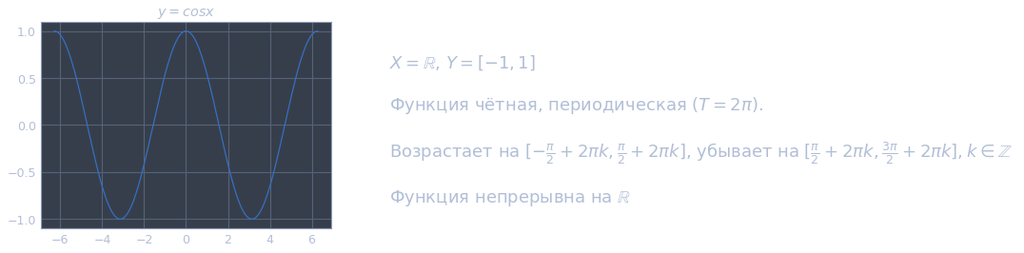

```python
x = np.linspace(- 2 * np.pi, 2 * np.pi, 200)
y = np.cos(x)

matplotlib.rcParams.update({'font.size': 18})

fig, axs = plt.subplots(1, 2, figsize=(12, 4))
axs[0].plot(x, y)
axs[0].set_title('$ y=cos x $')

axs[1].axis('off')
axs[1].text(0, 0.02, r"""
$ X = \mathbb{R} $, $ Y = [-1, 1] $

Функция чётная, периодическая ($ T = 2\pi $).

Возрастает на $ [-\frac{\pi}{2} + 2 \pi k, \frac{\pi}{2} + 2 \pi k] $, убывает на $ [\frac{\pi}{2} + 2 \pi k, \frac{3 \pi}{2} + 2 \pi k], k \in \mathbb{Z} $

Функция непрерывна на $ \mathbb{R} $
""")
plt.show()
```

### Задача 3

#### Определение точной верхней грани числового множества {x}

Число $ M^* $ называется точной верхней границей $ A $, если:

1. $ a \leqslant M^* \space \forall \space a \in A $
2. $ \forall x \in \mathbb{R}, x < M^*, \forall \space a' \in A \space \space a > x $

### Задача 4

#### Определение по Гейне: неверно, что $ \space \lim\limits_{x \to -\infty} f(x) = b $

Неверно, что $ b \in \mathbb{R} $ является пределом функции f, если $ \exists \space \{x_n\} $ аргументов, т.ч. $x_n \underset{n \to \infty}{\to} -\infty: f(x_n) \not\to b$

### Задача 5

#### Дать определение: $ \phi(x) \sim \psi(x), x \to a-0 $

Если $ \exists \lim\limits_{x \to a - 0} \frac{\phi(x)}{\psi(x)} = 1 $, то $ \phi(x) \sim \psi(x), x \to a - 0 $